# Documentation: A Brief Overview

Robert Sholl

2024-11-06

# Introduction

### 1. What is documentation

### 2. Why do we document

### 3. Why you should document

### 4. How you can document

### 5. The Good, the Bad, and the Ugly

### 6. Wrap-up

# What is documentation

> Documentation is just a method of recording information

**Specifically it records**

#### 1. How a process was performed

- What did you do
- What steps did you take
- Why were the steps taken in that order
- What did you use to do it

#### 2. Comments on how the process went

- Troubleshooting processes you used
- Errors you encountered
- Alternative methods you may have tried

#### 3. Outputs/products of the process

- If you ran code show the output
- If you made plots include them
- If you built an app show where to find it

#### 4. How to perform the same process

- Step-by-step instructions
- Definition of what is **mandatory** to do and what is **optional**
- Can someone successfully reproduce the process with no previous experience?
  - If not, what experience do they need/is recommended?

In general we want to hit **all four of these points**

It’s OK to only hit three, but recognize what you’ve provided

- [1,2,4] makes a **guide**, [1,2,3] makes a **report**

2 or less points hit produce incomplete documentation

- Incomplete documentation is as destructive than no documentation
- [1,2] doesn’t inform someone how to do what you did, or what the outcome will look like
- [2,3] leaves the reader in the dark about what you actually did
- [1,3] puts the burden of reproducibility and error troubleshooting on the reader

# Why do we document

> An informed and careful reader shouldn’t be confused

Someone with all the necessary background of what you’re doing shouldn’t question:

- What you did
- Why you did it
- How you did it
- What tools you used

It’s OK but not *ideal* if they don’t know **why you did it that way**

> Your steps should always be reproducible

If your steps aren’t reproducible then your results **aren’t real**

- Nobody can confirm you did them right
- Nobody can confirm **you did them**

# Why you should document

##### a) Your final project involves documentation; I’m one of the graders

##### b) Industry revolves around documentation, **especially in any programming related industry**

- Where I came from it was *mandatory*

##### c) Academia is essentially founded on it

- $(+)$ We’re in a reproducibility crisis, stand out, stay employed

##### d) The you of today won’t have the same brain as the you of $2+$ years from now

- And that person may need to know what you were thinking

##### e) Constantly answering the same question is tedious and wastes your time

# How you can document

> My preferred method of documentation for programming is actually code comments

```r
dijk_func <- function(matrix,init_node){

  ############################
  ### initialize variables ###
  ############################

  ## set initial distances for all vertices ##

  # variable to store distances
  # inf for all non-source vertices
  dist <- rep(Inf,nrow(matrix))

  # 0 for source vertex
  dist[init_node] <- 0

  # logic repetition across the matrix
  # provides a binary operation to confirm visit or no visit
  visited <- rep(FALSE,nrow(matrix))

  #############################################
  ### repeat until all vertices are checked ###
  #############################################

  # logical repition of the algorithm
  # until all nodes have been visited
  repeat{

    # until any node is checked it is assumed
    # the distance of shortest path (sp) is infinite
    shortest_path = Inf

    # index for checking if visits have occurred
    i_v = -1

    # for the k^th try, sequence the length of the distances
    for(k in seq_along(dist)) {
      # through all unvisited nodes

      # logic statement
      # if the distance at k^th try is less than sp
      # AND has NOT been visited at k^th try
      if(dist[k] < shortest_path && !visited[k]){
        # then sp is equal to distance at k^th try
        shortest_path = dist[k]
        # and index is set to k^th try
        i_v = k
      }
  }
    # given i_v is  equal to -1
    if(i_v == -1){
      # all nodes are visted
      # sequence is broken
      # output returned
      return (dist)
    }

    ##############################################################
    ### choose the unvisited vertex with the shortest distance ###
    ########## from the start to be the current vertex ###########
    ##### always start with the source as the current vertex #####
    ##############################################################

    # for k^th try across the adj matrix
    # in the indexed visits
    for(k in seq_along(matrix[i_v,])) {

      ####################################################################
      ### for each of the current vertex's unvisited neighbor vertices ###
      ############## calculate the distance from the source ##############
      ### update the distance if the new calculated distance is lower ####
      ####################################################################

      # if the path is NOT equal to 0
      # AND the distrance at k^th try is less than than the indexed distance
      # over the edge at that point
      if(matrix[i_v,k] != 0 && dist[k] > dist[i_v] + matrix[i_v,k]){

        # this becomes the new shortest path
        dist[k] = dist[i_v] + matrix[i_v,k]
      }

      ############################################
      ###### mark checked vertex as visited ######
      ### marked vertices aren't checked again ###
      ############################################

      # replace false values for no visit with true given they've been visited
      visited[i_v] <- TRUE
    }
  }
}
```

> Markdown platforms are a fantastic method
- Quarto
- Jupyter
- R Markdown

> Non-programming documentation has analogous platforms
- Obsidian Vault
- Notion
- Overleaf (LaTeX)

# The Good, the Bad, and the Ugly

### Good

> Detailed comments that assume the reader is **clueless**

```r
# table() will provide a frequency each node occurs in the list
# so long as our assumption on how to calculate node degree holds
degree_dist_f <- data.frame(table(vector_stack_f)) # each table is placed in a data frame
degree_dist_p <- data.frame(table(vector_stack_p)) # so that results are easily referenced
```

> Important figures made **as readable as possible**

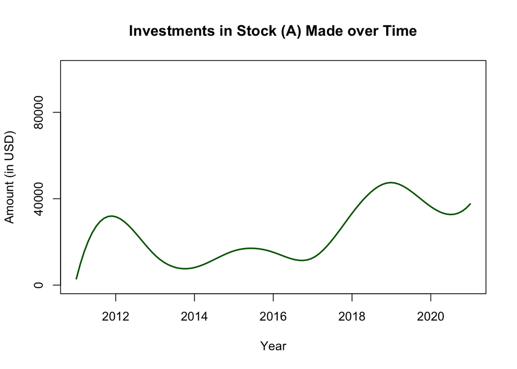

> Inclusion of common errors and troubleshooting/resolution

```
When attempting to log-in to bookdown.org/connect if you experience this error sequence:

- Log-in via Google authentication

- Load back to the original log-in page

- A brief error message is added to the end of the URL

- Dev Tools for your browser shows a 401 error code

The resolution that worked for this instance was:

- Create a new Google account

- Connect all multi-factor authentication available

- Connect to bookdown.org with that new account

If that does not work, the original solution involved making the Google account out of an existing outlook account.
```

### Bad

> Assuming the reader understands what your variables and shorthands are

```r
# gen adj mat
for (e in e_f) {
  u <- e[1]
  v <- e[2]
  F_ij[u + 1, v + 1] <- 1
  F_ij[v + 1, u + 1] <- 1
}
```

> Putting multiple pages of unnecessary output between sections/sentences

```
This resulted in an intermediary product of shortest path arrays for each network at 115x115x10:

print[sp_F_array]
print[sp_P_array]

Now we can use these arrays in producing the necessary parameters for our K-Nearest-Neighbors algorithm.
```

The same logic applies to message/error/warning outputs, don’t let those through unless they’re **part of what you’re documenting**

> Off-loading short/medium length explanations of functions to separate documents

**What does this mean?**

- Wikipedia-style documentation does not work as a step-by-step
- Citations are good, but don’t make every piece of background a citation rabbit hole
- That works in academic papers, it never works in technical documentation
- This format is occasionally useful if you’re running manual/blog/book style documentation and the link is within the same document or to something **you have written yourself**
- Try not to disrupt the reader’s information pipeline by frequently changing the author that’s delivering the information

### Ugly

- Poorly cropped/scaled screenshots
- Dependency-required file formats (.docx, .xlsx, .hjsl, .gml, .Rmd, .R, .qmd)
- Leaving the rationale for a process up to interpretation
- Poor differentiation between code/algorithm and explanation
- Code running off the page and becoming inaccessible
- Missing seeds for random number generation processes

# Warp-Up

> **Poor documentation** is just as bad as **no documentation**.

> It’s always better to start with being overly detailed and scaling back.

> Don’t default to what you’re **comfortable** with, **try different** methods and platforms **whenever you can**.

> **Everything** you’ve seen here today was learned by **using Google correctly**. **You don’t need a class** to become good at this (or programming) you just need to put in effort.

> You may not feel the outcomes of being a poor documenter right away, but eventually you will and it usually comes in the form of a **capped salary**. On occasion it can **lose you a job**.